# 学习R

#### 独立样本T检验

**独立样本t检验**（Independent Samples t-test）用于比较**两组独立数据**的均值是否存在显著差异。

步骤：检查两组数据是否是连续型——检查两组数据是否服从正态分布——检查数据两组数据是否方差齐性——T检验——结果可视化

**对于非正态数据**：考虑使用非参数检验（如Mann-Whitney U检验，**`wilcox.test(value ~ group, data = data)`**）。

```r
# 以iris的两列数据比较作为示例
head(iris)
```

```
##   Sepal.Length Sepal.Width Petal.Length Petal.Width Species
## 1          5.1         3.5          1.4         0.2  setosa
## 2          4.9         3.0          1.4         0.2  setosa
## 3          4.7         3.2          1.3         0.2  setosa
## 4          4.6         3.1          1.5         0.2  setosa
## 5          5.0         3.6          1.4         0.2  setosa
## 6          5.4         3.9          1.7         0.4  setosa
```

```r
# 根据一列分组变量提取对应列的数据和组数据，这里我们根据Species的分组变量，对setosa和versicolor两组及其对应的Sepal.Length数据提取出来
iris_T <- subset(iris, Species %in% c("setosa", "versicolor"),
                      select = c("Sepal.Length", "Species"))

# 比较sepal.length在setosa和versicolor两个品种间是否有差异

# 用Shapiro-Wilk检验或QQ图对两组数据的正太性进行检验,p>0.05,认为服从正太分布

shapiro_setosa <- shapiro.test(iris_T$Sepal.Length[iris_T$Species=='setosa'])  #
shapiro_versicolor <- shapiro.test(iris_T$Sepal.Length[iris_T$Species=='versicolor'])  #
print(c(shapiro_setosa,shapiro_versicolor))
```

```
## $statistic
##         W
## 0.9776985
##
## $p.value
## [1] 0.4595132
##
## $method
## [1] "Shapiro-Wilk normality test"
##
## $data.name
## [1] "iris_T$Sepal.Length[iris_T$Species == \"setosa\"]"
##
## $statistic
##         W
## 0.9778357
##
## $p.value
## [1] 0.464737
##
## $method
## [1] "Shapiro-Wilk normality test"
##
## $data.name
## [1] "iris_T$Sepal.Length[iris_T$Species == \"versicolor\"]"
```

```r
# 方差齐性检验,P>0.05认为方差齐性
library(car)
leveneTest(iris_T$Sepal.Length,iris_T$Species,data = iris)
```

```
## Levene's Test for Homogeneity of Variance (center = median: iris)
##       Df F value   Pr(>F)
## group  1  8.1727 0.005196 **
##       98
## ---
## Signif. codes:  0 '***' 0.001 '**' 0.01 '*' 0.05 '.' 0.1 ' ' 1
```

```r
# 执行t检验
# 若方差齐性（var.equal = TRUE）：使用Student's t-test。
# 若方差不齐（var.equal = FALSE）：使用Welch's t-test（默认）

t.test(iris_T$Sepal.Length[iris_T$Species=='setosa'],
       iris$Sepal.Length[iris$Species=='versicolor'],var.equal = T)  # 方差齐性
```

```
##
##  Two Sample t-test
##
## data:  iris_T$Sepal.Length[iris_T$Species == "setosa"] and iris$Sepal.Length[iris$Species == "versicolor"]
## t = -10.521, df = 98, p-value < 2.2e-16
## alternative hypothesis: true difference in means is not equal to 0
## 95 percent confidence interval:
##  -1.1054165 -0.7545835
## sample estimates:
## mean of x mean of y
##     5.006     5.936
```

```r
t.test(iris_T$Sepal.Length[iris_T$Species=='setosa'],
       iris_T$Sepal.Length[iris_T$Species=='versicolor'],var.equal = F)  # 方差不齐性
```

```
##
##  Welch Two Sample t-test
##
## data:  iris_T$Sepal.Length[iris_T$Species == "setosa"] and iris_T$Sepal.Length[iris_T$Species == "versicolor"]
## t = -10.521, df = 86.538, p-value < 2.2e-16
## alternative hypothesis: true difference in means is not equal to 0
## 95 percent confidence interval:
##  -1.1057074 -0.7542926
## sample estimates:
## mean of x mean of y
##     5.006     5.936
```

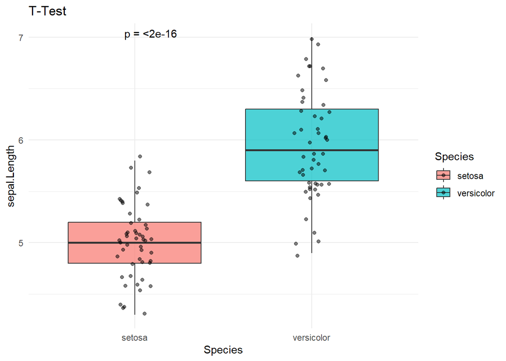

```r
# 结果可视化
library(ggplot2)
library(ggpubr)  # 用于添加统计标记

ggplot(iris_T, aes(x = Species, y = Sepal.Length, fill = Species)) +
  geom_boxplot(alpha = 0.7) +
  geom_jitter(width = 0.1, alpha = 0.5) +  # 显示数据点
  stat_compare_means(method = "t.test", label = "p.format") +  # 添加p值
  labs(title = "T-Test", x = "Species", y = "sepal.Length") +
  theme_minimal()
```

#### 配对样本T检验

用于比较**同一组受试对象**在两种不同条件下的测量值是否存在显著差异（如治疗前后、两种方法的测量结果等）

**实际数据格式要求：**

- 两列数值变量（必须长度相同）。
- 每行代表同一受试对象的配对测量。

**检查配对t检验的假设**

配对t检验需满足：

1. **配对性**：数据必须是同一组对象的两次测量。
2. **差值正态性**：两列数据的差值近似服从正态分布（可用Shapiro-Wilk检验或QQ图检验）。

对于不服从正态分布的数据，改用**Wilcoxon符号秩检验**（非参数替代）wilcox.test(paired_data$condition_A, paired_data$condition_B, paired = TRUE)

```r
# 创建配对数据

paired_data <- data.frame(
  flower_id = 1:50,  # 50朵setosa花
  condition_A = iris$Sepal.Length[iris$Species == "setosa"],  # 条件A的测量值
  condition_B = iris$Sepal.Length[iris$Species == "setosa"] + rnorm(50, mean = 0.5, sd = 0.3)  # 条件B的测量值（人为添加差异）
)

# 查看前6行
head(paired_data)
```

```
##   flower_id condition_A condition_B
## 1         1         5.1    5.538725
## 2         2         4.9    5.285847
## 3         3         4.7    5.039327
## 4         4         4.6    4.693537
## 5         5         5.0    5.215560
## 6         6         5.4    5.989070
```

```r
#  检查差值正态性

# 计算差值
differences <- paired_data$condition_B - paired_data$condition_A

# Shapiro-Wilk检验
shapiro_test <- shapiro.test(differences)
print(shapiro_test)  # p值 > 0.05说明差值服从正态分布
```

```
##
##  Shapiro-Wilk normality test
##
## data:  differences
## W = 0.96959, p-value = 0.2227
```

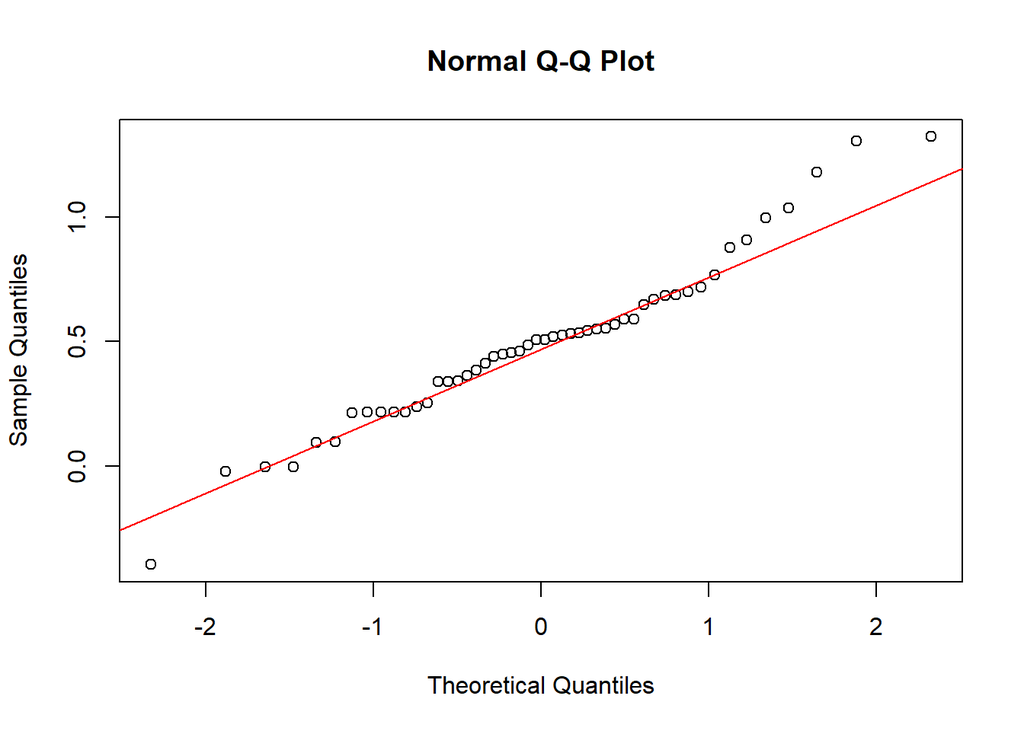

```r
# QQ图可视化
qqnorm(differences)
qqline(differences, col = "red")
```

```r
# 执行配对T检验
t_test_result <- t.test(
  paired_data$condition_A,
  paired_data$condition_B,
  paired = TRUE,  # 关键参数，对于配对T检验，指定为T
  alternative = "two.sided"  # 双侧检验（默认）
)

print(t_test_result)
```

```
##
##  Paired t-test
##
## data:  paired_data$condition_A and paired_data$condition_B
## t = -10.455, df = 49, p-value = 4.506e-14
## alternative hypothesis: true mean difference is not equal to 0
## 95 percent confidence interval:
##  -0.5923912 -0.4013730
## sample estimates:
## mean difference
##      -0.4968821
```

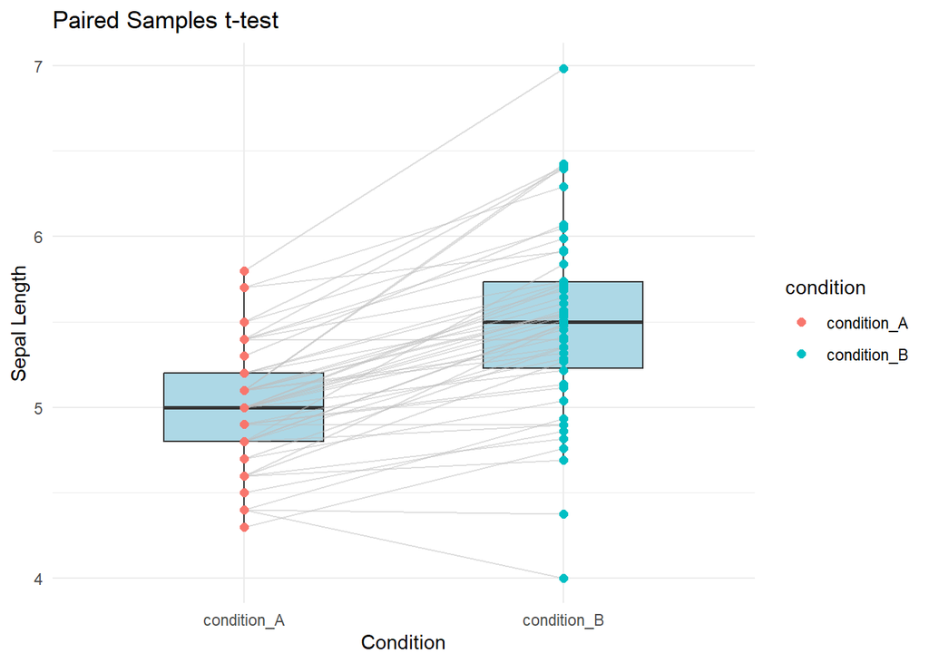

```r
# 结果可视化
# 方法1：箱线图 + 配对线（适合少量数据点）
library(ggplot2)
library(tidyr)

# 转换数据为长格式
paired_long <- pivot_longer(
  paired_data,
  cols = c("condition_A", "condition_B"),
  names_to = "condition",
  values_to = "sepal_length"
)

# 绘制箱线图 + 配对线
ggplot(paired_long, aes(x = condition, y = sepal_length)) +
  geom_boxplot(width = 0.5, fill = "lightblue") +
  geom_line(aes(group = flower_id), color = "gray", alpha = 0.5) +  # 配对线
  geom_point(aes(color = condition), size = 2) +
  labs(title = "Paired Samples t-test", x = "Condition", y = "Sepal Length") +
  theme_minimal()
```

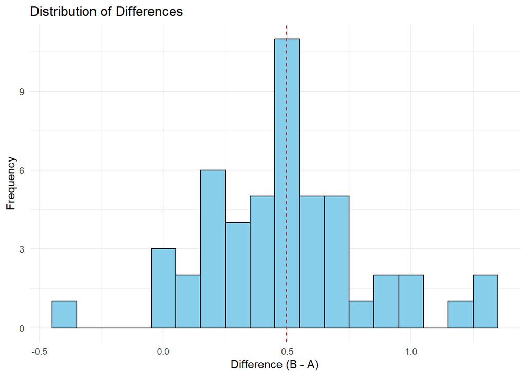

```r
# 方法2：差异分布直方图
ggplot(data.frame(differences), aes(x = differences)) +
  geom_histogram(binwidth = 0.1, fill = "skyblue", color = "black") +
  geom_vline(xintercept = mean(differences), color = "red", linetype = "dashed") +
  labs(title = "Distribution of Differences", x = "Difference (B - A)", y = "Frequency") +
  theme_minimal()
```

### 4.2.2、方差分析

方差分析(ANOVA)用于比较三个及以上样本均值的差异。根据因素的个数,方差分析可分为单因素方差分析和多因素方差分析。

#### 单因素方差分析

**检验方差齐性：**使用 **Levene检验**（对非正态数据更稳健）或 **Bartlett检验**（需数据正态）

**执行ANOVA**

**事后检验（多重比较）**

```r
# 以iris数据为例，比较不同Species（setosa, versicolor, virginica）的 Sepal.Length 均值差异。

iris
```

[output not shown]

[output cut: 136 more lines]

```r
head(iris)
```

```
##   Sepal.Length Sepal.Width Petal.Length Petal.Width Species
## 1          5.1         3.5          1.4         0.2  setosa
## 2          4.9         3.0          1.4         0.2  setosa
## 3          4.7         3.2          1.3         0.2  setosa
## 4          4.6         3.1          1.5         0.2  setosa
## 5          5.0         3.6          1.4         0.2  setosa
## 6          5.4         3.9          1.7         0.4  setosa
```

```r
# 方差齐性检验, Levene检验（对非正态数据更稳健）或Bartlett检验（需数据正态）：
library(car)

leveneTest(Sepal.Length ~ Species, data = iris) # p > 0.05说明方差齐性
```

```
## Levene's Test for Homogeneity of Variance (center = median)
##        Df F value   Pr(>F)
## group   2  6.3527 0.002259 **
##       147
## ---
## Signif. codes:  0 '***' 0.001 '**' 0.01 '*' 0.05 '.' 0.1 ' ' 1
```

```r
bartlett.test(Sepal.Length ~ Species, data = iris)
```

```
##
##  Bartlett test of homogeneity of variances
##
## data:  Sepal.Length by Species
## Bartlett's K-squared = 16.006, df = 2, p-value = 0.0003345
```

```r
# 执行方差分析（ANOVA)
anova_result <- aov(Sepal.Length ~ Species, data = iris)
summary(anova_result)
```

```
##              Df Sum Sq Mean Sq F value Pr(>F)
## Species       2  63.21  31.606   119.3 <2e-16 ***
## Residuals   147  38.96   0.265
## ---
## Signif. codes:  0 '***' 0.001 '**' 0.01 '*' 0.05 '.' 0.1 ' ' 1
```

```r
# 事后检验（多重比较）
TukeyHSD(anova_result)  # 输出各组间的p值和差异
```

```
##   Tukey multiple comparisons of means
##     95% family-wise confidence level
##
## Fit: aov(formula = Sepal.Length ~ Species, data = iris)
##
## $Species
##                       diff       lwr       upr p adj
## versicolor-setosa    0.930 0.6862273 1.1737727     0
## virginica-setosa     1.582 1.3382273 1.8257727     0
## virginica-versicolor 0.652 0.4082273 0.8957727     0
```

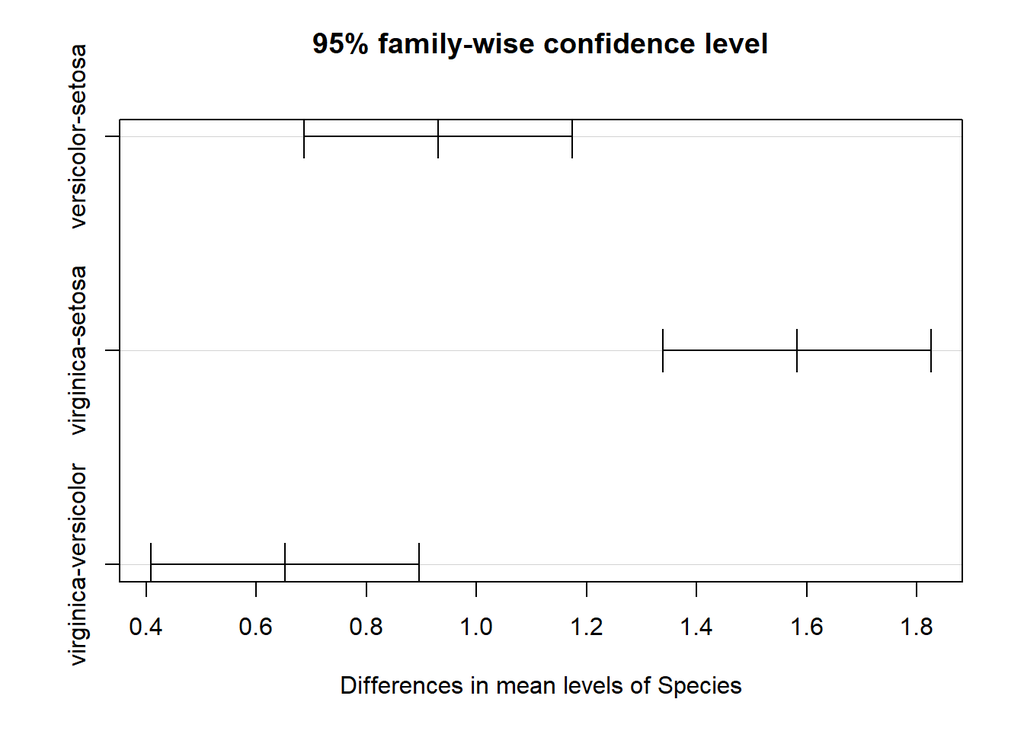

```r
plot(TukeyHSD(anova_result))  # 可视化置信区间
```

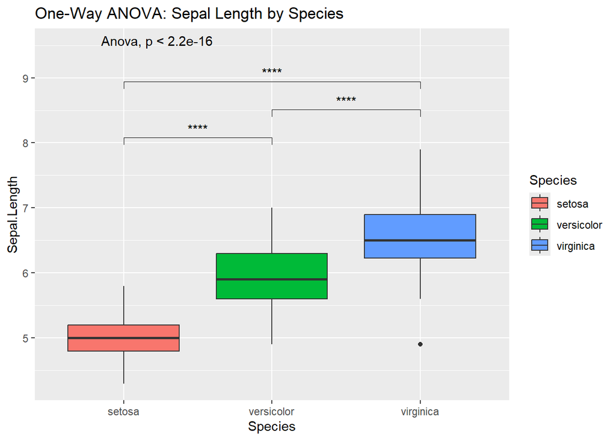

```r
# 统计分析结果的可视化
# 箱线图 + 显著性标记（ggplot2 + ggpubr）
library(ggplot2)
library(ggpubr)

ggplot(iris, aes(x = Species, y = Sepal.Length, fill = Species)) +
  geom_boxplot() +
  stat_compare_means(method = "anova", label.y = 9.5) +  # 添加ANOVA p值
  stat_compare_means(comparisons = list(c("setosa", "versicolor"),
                     c("versicolor", "virginica"),c('setosa','virginica')),
                   method = "t.test", label = "p.signif") +  # 组间比较
  labs(title = "One-Way ANOVA: Sepal Length by Species")
```

( **非参数替代（当数据不满足ANOVA假设）:**若数据不满足正态性或方差齐性，使用 **Kruskal-Wallis检验**（单因素）或 **Friedman检验**（重复测量）)

```r
# 单因素非参数检验
kruskal.test(Sepal.Length ~ Species, data = iris)
```

```
##
##  Kruskal-Wallis rank sum test
##
## data:  Sepal.Length by Species
## Kruskal-Wallis chi-squared = 96.937, df = 2, p-value < 2.2e-16
```

```r
# 事后比较（Dunn检验）
library(FSA)
dunnTest(Sepal.Length ~ Species, data = iris, method = "bonferroni")
```

```
## Dunn (1964) Kruskal-Wallis multiple comparison
```

```
##   p-values adjusted with the Bonferroni method.
```

```
##               Comparison         Z      P.unadj        P.adj
## 1    setosa - versicolor -6.106326 1.019504e-09 3.058513e-09
## 2     setosa - virginica -9.741785 2.000099e-22 6.000296e-22
## 3 versicolor - virginica -3.635459 2.774866e-04 8.324597e-04
```

#### **双因素方差分析（Two-Way ANOVA）**

以 **`ToothGrowth`** 数据集为例，分析牙齿长度（**`len`**）受 **剂量（`dose`）** 和 **补充剂类型（`supp`）** 的影响

```r
# 数据准备：
data(ToothGrowth)
ToothGrowth$dose <- factor(ToothGrowth$dose)  # 将剂量转为因子
head(ToothGrowth)
```

```
##    len supp dose
## 1  4.2   VC  0.5
## 2 11.5   VC  0.5
## 3  7.3   VC  0.5
## 4  5.8   VC  0.5
## 5  6.4   VC  0.5
## 6 10.0   VC  0.5
```

```r
# 执行双因素ANOVA（含交互作用）：supp:dose：交互作用项（p < 0.05表示两者对结果有协同影响）。
anova_two_way <- aov(len ~ supp * dose, data = ToothGrowth)
summary(anova_two_way)
```

```
##             Df Sum Sq Mean Sq F value   Pr(>F)
## supp         1  205.4   205.4  15.572 0.000231 ***
## dose         2 2426.4  1213.2  92.000  < 2e-16 ***
## supp:dose    2  108.3    54.2   4.107 0.021860 *
## Residuals   54  712.1    13.2
## ---
## Signif. codes:  0 '***' 0.001 '**' 0.01 '*' 0.05 '.' 0.1 ' ' 1
```

```r
library(emmeans)
```

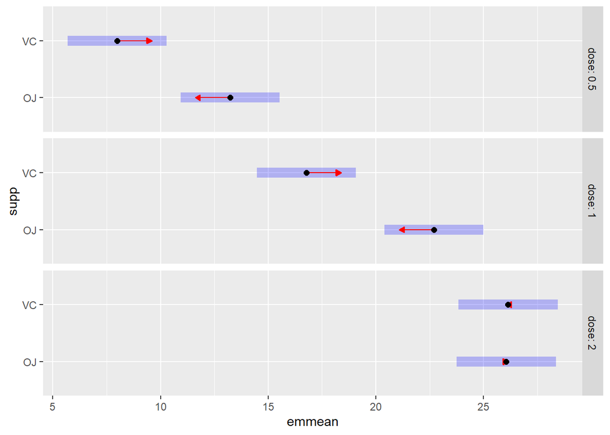

```r
emm <- emmeans(anova_two_way, pairwise ~ supp | dose)  # 按剂量分组比较supp
plot(emm, comparisons = TRUE)  # 可视化
```

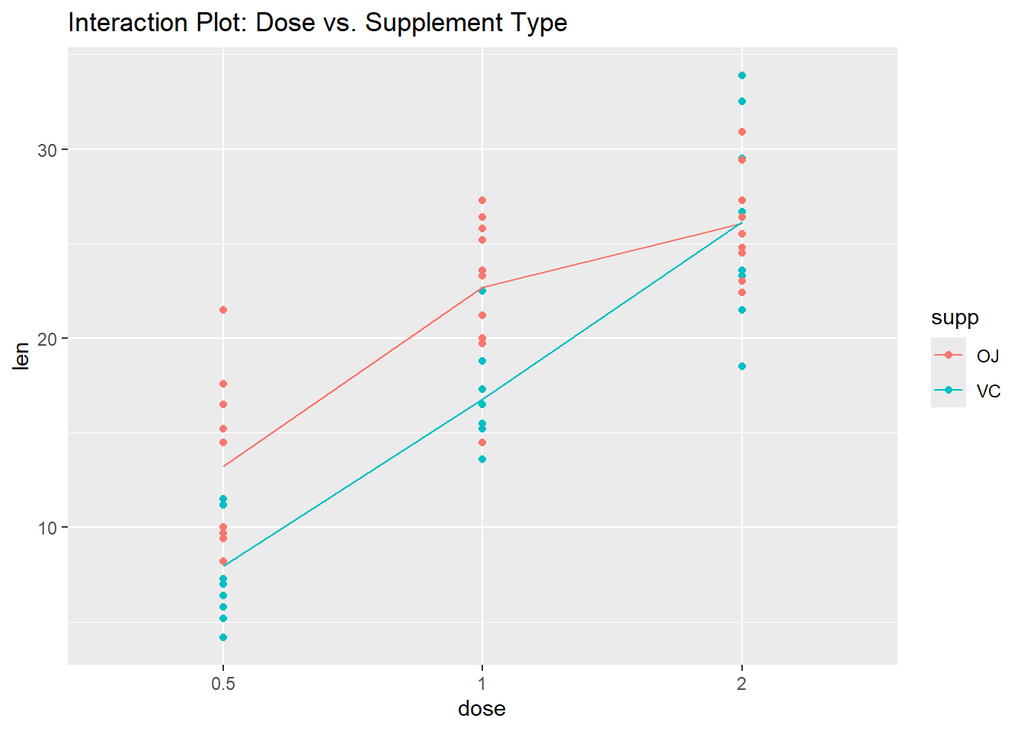

```r
# 交互作用图（双因素ANOVA）：
ggplot(ToothGrowth, aes(x = dose, y = len, color = supp, group = supp)) +
  geom_point() +
  stat_summary(fun = mean, geom = "line") +  # 绘制均值连线
  labs(title = "Interaction Plot: Dose vs. Supplement Type")
```

### 4.2.3、卡方检验

主要用于分析**分类变量**之间的关联性或拟合优度,包括卡方独立性检验、卡方拟合优度检验

卡方独立性检验：检验两个分类变量是否独立（即是否存在关联）。

- 性别（男/女）与吸烟习惯（是/否）是否有关联？
- 广告类型（A/B/C）与购买意愿（高/中/低）是否相关？

```r
# 以Titanic数据集为例，分析乘客等级（Class）与生存状态（Survived）是否独立。

# 提取数据并转换为二维列联表
Titanic # 查看数据集
```

```
## , , Age = Child, Survived = No
##
##       Sex
## Class  Male Female
##   1st     0      0
##   2nd     0      0
##   3rd    35     17
##   Crew    0      0
##
## , , Age = Adult, Survived = No
##
##       Sex
## Class  Male Female
##   1st   118      4
##   2nd   154     13
##   3rd   387     89
##   Crew  670      3
##
## , , Age = Child, Survived = Yes
##
##       Sex
## Class  Male Female
##   1st     5      1
##   2nd    11     13
##   3rd    13     14
##   Crew    0      0
##
## , , Age = Adult, Survived = Yes
##
##       Sex
## Class  Male Female
##   1st    57    140
##   2nd    14     80
##   3rd    75     76
##   Crew  192     20
```

```r
data <- as.data.frame(Titanic)  # 将数据集转化为数据框
head(data)
```

```
##   Class    Sex   Age Survived Freq
## 1   1st   Male Child       No    0
## 2   2nd   Male Child       No    0
## 3   3rd   Male Child       No   35
## 4  Crew   Male Child       No    0
## 5   1st Female Child       No    0
## 6   2nd Female Child       No    0
```

```r
titanic_table <- xtabs(Freq ~ Class + Survived, data = data)  # 创建二维列联表
print(titanic_table)
```

```
##       Survived
## Class   No Yes
##   1st  122 203
##   2nd  167 118
##   3rd  528 178
##   Crew 673 212
```

```r
# 进行卡方检验
# X-squared：卡方统计量。
# df：自由度（(行数-1)*(列数-1)）。
# p-value：显著性（p < 0.05 表示变量显著相关）。

chi_test <- chisq.test(titanic_table)
print(chi_test)
```

```
##
##  Pearson's Chi-squared test
##
## data:  titanic_table
## X-squared = 190.4, df = 3, p-value < 2.2e-16
```

```r
chi_test$expected  # 期望频数
```

```
##       Survived
## Class        No       Yes
##   1st  220.0136 104.98637
##   2nd  192.9350  92.06497
##   3rd  477.9373 228.06270
##   Crew 599.1140 285.88596
```

```r
chi_test$residuals # Pearson残差（标准化残差）
```

```
##       Survived
## Class         No       Yes
##   1st  -6.607873  9.565772
##   2nd  -1.867159  2.702959
##   3rd   2.289965 -3.315027
##   Crew  3.018611 -4.369840
```

```r
# 结果可视化，颜色越深，观测值与期望值的偏差越大。
library(vcd)
```

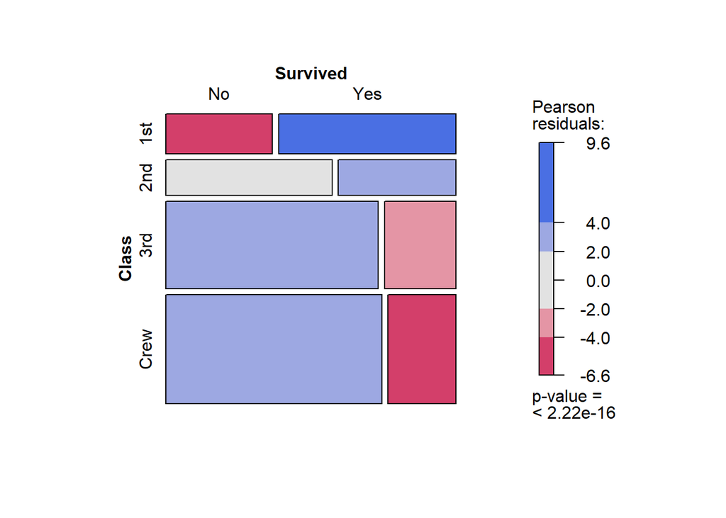

```r
mosaic(titanic_table, shade = TRUE, legend = TRUE)
```

```r
a = 2
switch(a,b = mean(a),a = a+3)
```

```
## [1] 5
```

### 4.2.4、相关性检验

相关性检验用于分析两个连续变量之间的线性关系（如身高与体重、广告投入与销售额

**效应量解读**

- **|r| < 0.3**：弱相关。
- **0.3 ≤ |r| < 0.7**：中等相关。
- **|r| ≥ 0.7**：强相关。

```r
# 以R内置数据集 mtcars 为例，分析 mpg（每加仑英里数）和 wt（车重）的相关性。

data(mtcars)
head(mtcars[, c("mpg", "wt")])
```

```
##                    mpg    wt
## Mazda RX4         21.0 2.620
## Mazda RX4 Wag     21.0 2.875
## Datsun 710        22.8 2.320
## Hornet 4 Drive    21.4 3.215
## Hornet Sportabout 18.7 3.440
## Valiant           18.1 3.460
```

```r
# Pearson相关系数（线性相关）：数据满足正态性和线性关系

# 计算Pearson相关系数
cor_pearson <- cor.test(mtcars$mpg, mtcars$wt, method = "pearson")
print(cor_pearson)
```

```
##
##  Pearson's product-moment correlation
##
## data:  mtcars$mpg and mtcars$wt
## t = -9.559, df = 30, p-value = 1.294e-10
## alternative hypothesis: true correlation is not equal to 0
## 95 percent confidence interval:
##  -0.9338264 -0.7440872
## sample estimates:
##        cor
## -0.8676594
```

```r
# Spearman秩相关（单调相关）：数据不满足正态性或存在非线性单调关系。

cor_spearman <- cor.test(mtcars$mpg, mtcars$wt, method = "spearman")
print(cor_spearman)
```

```
##
##  Spearman's rank correlation rho
##
## data:  mtcars$mpg and mtcars$wt
## S = 10292, p-value = 1.488e-11
## alternative hypothesis: true rho is not equal to 0
## sample estimates:
##       rho
## -0.886422
```

```r
# Kendall's Tau（有序数据或小样本）：样本量小或存在大量重复值。

cor_kendall <- cor.test(mtcars$mpg, mtcars$wt, method = "kendall")
print(cor_kendall)
```

```
##
##  Kendall's rank correlation tau
##
## data:  mtcars$mpg and mtcars$wt
## z = -5.7981, p-value = 6.706e-09
## alternative hypothesis: true tau is not equal to 0
## sample estimates:
##        tau
## -0.7278321
```

```r
#  多变量相关性矩阵：分析数据框中多个变量的相关性：
# 计算相关系数矩阵
cor_matrix <- cor(mtcars[, c("mpg", "wt", "hp", "disp")], method = "pearson")
print(cor_matrix)
```

```
##             mpg         wt         hp       disp
## mpg   1.0000000 -0.8676594 -0.7761684 -0.8475514
## wt   -0.8676594  1.0000000  0.6587479  0.8879799
## hp   -0.7761684  0.6587479  1.0000000  0.7909486
## disp -0.8475514  0.8879799  0.7909486  1.0000000
```

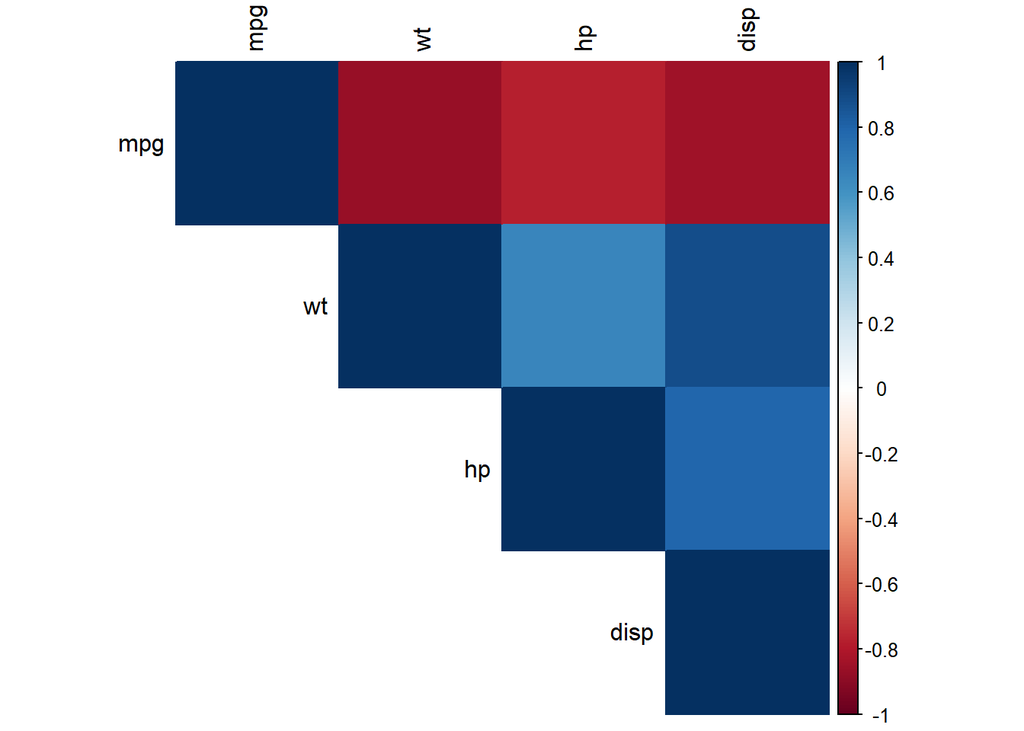

```r
# 可视化（热图）：红色表示负相关，蓝色表示正相关。
library(corrplot)
corrplot(cor_matrix, method = "color", type = "upper", tl.col = "black")
```

```r
# 偏相关分析（控制混杂变量）：在控制其他变量（如 hp）的条件下，分析 mpg 和 wt 的关系：
library(ppcor)
pcor_test <- pcor.test(mtcars$mpg, mtcars$wt, mtcars[, "hp"])
print(pcor_test) # 偏相关系数（estimate）和p值
```

```
##     estimate      p.value statistic  n gp  Method
## 1 -0.7512049 1.119647e-06 -6.128695 32  1 pearson
```

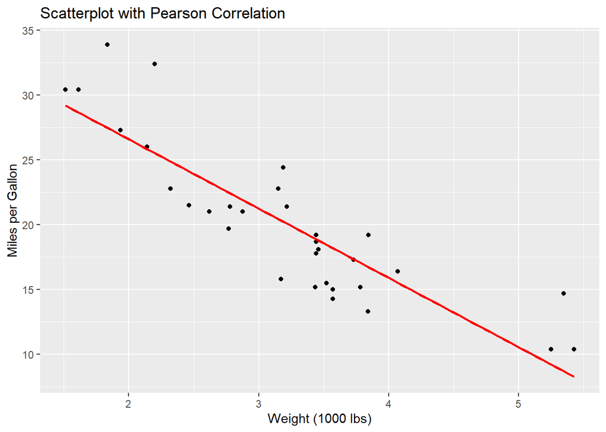

```r
# 可视化
# 散点图+回归线
library(ggplot2)
ggplot(mtcars, aes(x = wt, y = mpg)) +
  geom_point() +
  geom_smooth(method = "lm", se = FALSE, color = "red") +
  labs(title = "Scatterplot with Pearson Correlation",
       x = "Weight (1000 lbs)", y = "Miles per Gallon")
```

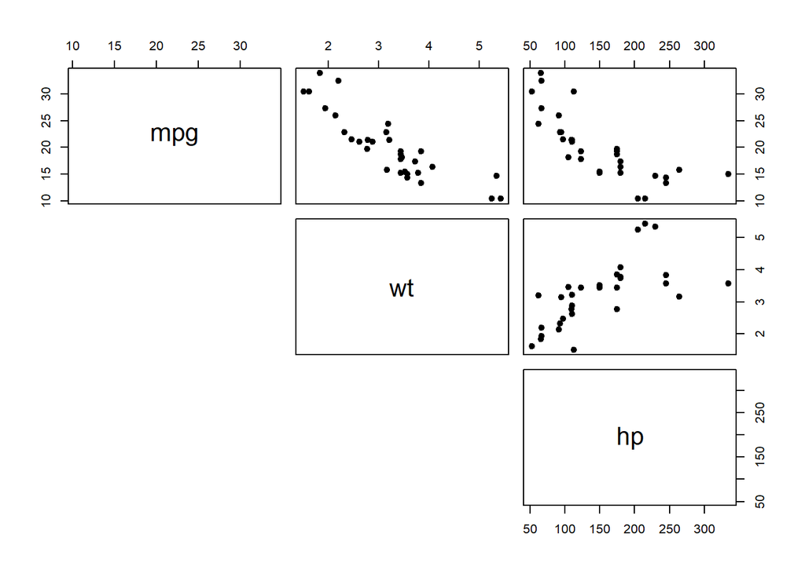

```r
# 散点图矩阵
pairs(mtcars[, c("mpg", "wt", "hp")], pch = 19, lower.panel = NULL)
```

## 4.3、回归分析

**回归分析**可以帮助你探索变量之间的因果关系或预测关系

线性回归、逻辑回归、其他回归模型（泊松回归、岭回归）

简单线性回归：用于分析**连续型因变量**与一个或多个自变量之间的关系。

- **Coefficients（系数）**：
  - **`Estimate`**：回归系数（斜率）。
  - **`Std. Error`**：标准误。
  - **`t value`**：t统计量。
  - **`Pr(>|t|)`**：p值（**p < 0.05** 表示显著）。
- **R-squared**：模型解释的变异比例（0~1，越大越好）。
- **F-statistic**：整体模型显著性。

```r
# 使用R内置的 mtcars 数据集，预测每加仑英里数（mpg）与车重（wt）和马力（hp）的关系：
data(mtcars)
head(mtcars[, c("mpg", "wt", "hp")])
```

```
##                    mpg    wt  hp
## Mazda RX4         21.0 2.620 110
## Mazda RX4 Wag     21.0 2.875 110
## Datsun 710        22.8 2.320  93
## Hornet 4 Drive    21.4 3.215 110
## Hornet Sportabout 18.7 3.440 175
## Valiant           18.1 3.460 105
```

```r
# 简单线性回归
# 拟合模型：mpg ~ wt
model_lm <- lm(mpg ~ wt, data = mtcars) # 拟合模型
summary(model_lm)
```

```
##
## Call:
## lm(formula = mpg ~ wt, data = mtcars)
##
## Residuals:
##     Min      1Q  Median      3Q     Max
## -4.5432 -2.3647 -0.1252  1.4096  6.8727
##
## Coefficients:
##             Estimate Std. Error t value Pr(>|t|)
## (Intercept)  37.2851     1.8776  19.858  < 2e-16 ***
## wt           -5.3445     0.5591  -9.559 1.29e-10 ***
## ---
## Signif. codes:  0 '***' 0.001 '**' 0.01 '*' 0.05 '.' 0.1 ' ' 1
##
## Residual standard error: 3.046 on 30 degrees of freedom
## Multiple R-squared:  0.7528, Adjusted R-squared:  0.7446
## F-statistic: 91.38 on 1 and 30 DF,  p-value: 1.294e-10
```

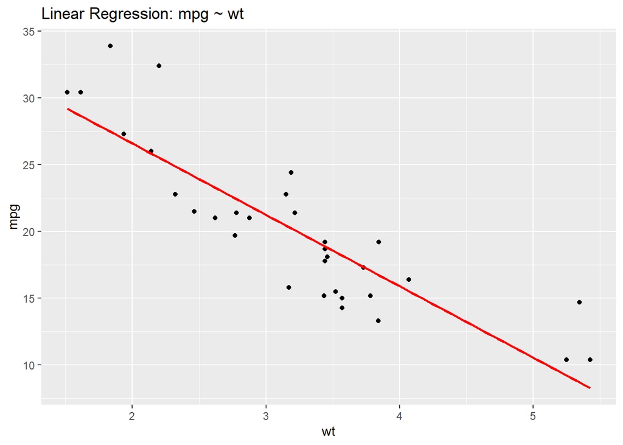

```r
# 可视化
library(ggplot2)
ggplot(mtcars, aes(x = wt, y = mpg)) +
  geom_point() +
  geom_smooth(method = "lm", se = FALSE, color = "red") +
  labs(title = "Linear Regression: mpg ~ wt")
```

多元线性回归

```r
# 拟合模型：mpg ~ wt + hp
model_lm_multi <- lm(mpg ~ wt + hp, data = mtcars)
summary(model_lm_multi)
```

```
##
## Call:
## lm(formula = mpg ~ wt + hp, data = mtcars)
##
## Residuals:
##    Min     1Q Median     3Q    Max
## -3.941 -1.600 -0.182  1.050  5.854
##
## Coefficients:
##             Estimate Std. Error t value Pr(>|t|)
## (Intercept) 37.22727    1.59879  23.285  < 2e-16 ***
## wt          -3.87783    0.63273  -6.129 1.12e-06 ***
## hp          -0.03177    0.00903  -3.519  0.00145 **
## ---
## Signif. codes:  0 '***' 0.001 '**' 0.01 '*' 0.05 '.' 0.1 ' ' 1
##
## Residual standard error: 2.593 on 29 degrees of freedom
## Multiple R-squared:  0.8268, Adjusted R-squared:  0.8148
## F-statistic: 69.21 on 2 and 29 DF,  p-value: 9.109e-12
```

模型诊断

检查回归假设（线性、正态性、同方差性、无多重共线性）：

- **残差 vs. 拟合值**：检查线性关系（应无趋势）。
- **QQ图**：检查残差正态性（点应接近直线）。
- **Scale-Location图**：检查同方差性（残差波动应均匀）。
- **Cook’s距离**：检查异常值。

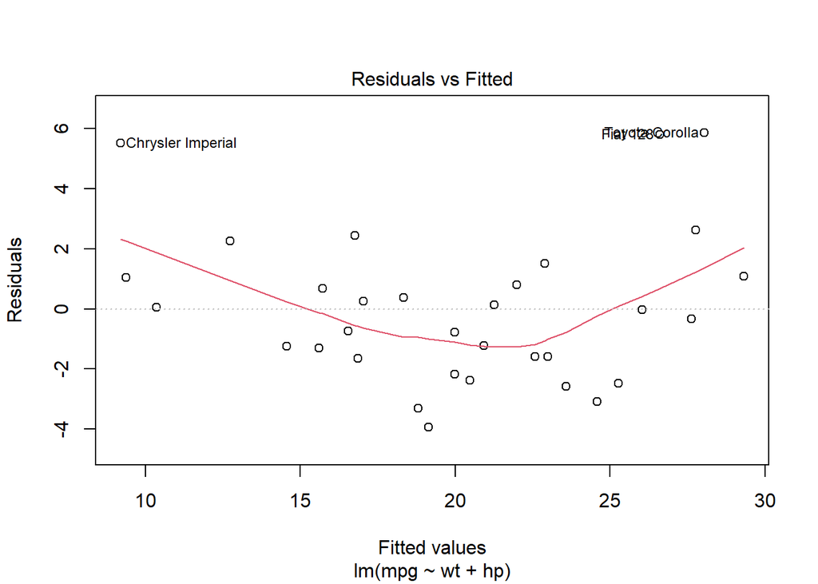

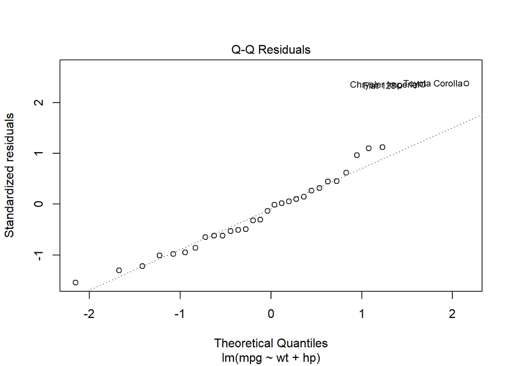

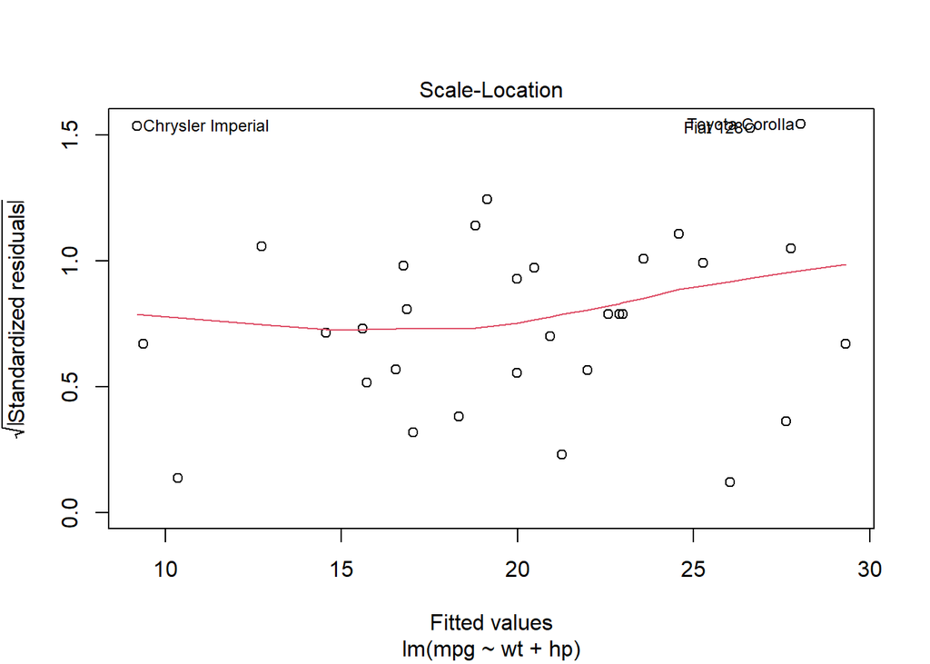

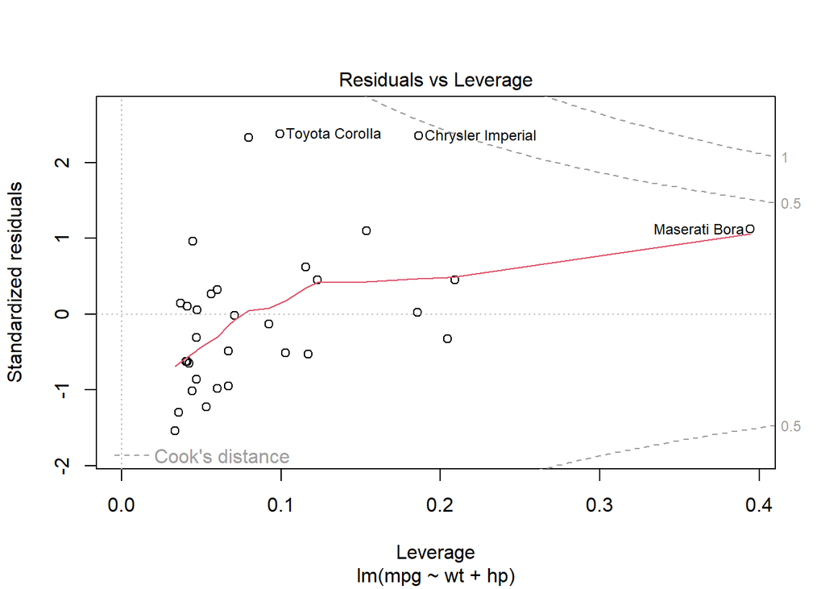

```r
# 绘制诊断图
# par(mfrow = c(2, 2))
plot(model_lm_multi)
```

多种共线性检验

```r
library(car)
vif(model_lm_multi)  # 方差膨胀因子（VIF > 5 表示共线性严重）
```

```
##       wt       hp
## 1.766625 1.766625
```

逻辑回归

用于分析**二分类因变量**（如0/1、Yes/No）与自变量的关系。

- **Coefficients**：
  - **`Estimate`**：对数几率比（log-odds）。
  - **`Pr(>|z|)`**：p值（**p < 0.05** 表示显著）。
- **AIC**：模型拟合优度（越小越好）

```r
# 使用 Titanic 数据集（需转换）为例

library(titanic)
data <- titanic_train[, c("Survived", "Age", "Fare", "Sex")]
data <- na.omit(data)  # 去除缺失值
head(data)
```

```
##   Survived Age    Fare    Sex
## 1        0  22  7.2500   male
## 2        1  38 71.2833 female
## 3        1  26  7.9250 female
## 4        1  35 53.1000 female
## 5        0  35  8.0500   male
## 7        0  54 51.8625   male
```

```r
# 拟合逻辑回归模型
model_logit <- glm(Survived ~ Age + Fare + Sex,
                   data = data,
                   family = binomial(link = "logit"))
summary(model_logit)
```

```
##
## Call:
## glm(formula = Survived ~ Age + Fare + Sex, family = binomial(link = "logit"),
##     data = data)
##
## Coefficients:
##              Estimate Std. Error z value Pr(>|z|)
## (Intercept)  0.934841   0.239101   3.910 9.24e-05 ***
## Age         -0.010570   0.006498  -1.627    0.104
## Fare         0.012773   0.002696   4.738 2.16e-06 ***
## Sexmale     -2.347599   0.189956 -12.359  < 2e-16 ***
## ---
## Signif. codes:  0 '***' 0.001 '**' 0.01 '*' 0.05 '.' 0.1 ' ' 1
##
## (Dispersion parameter for binomial family taken to be 1)
##
##     Null deviance: 964.52  on 713  degrees of freedom
## Residual deviance: 716.07  on 710  degrees of freedom
## AIC: 724.07
##
## Number of Fisher Scoring iterations: 5
```

```r
# 计算几率比
exp(coef(model_logit))  # 几率比（OR > 1表示正影响）
```

```
## (Intercept)         Age        Fare     Sexmale
##  2.54680790  0.98948613  1.01285487  0.09559845
```

```r
# 模型评估
library(pROC)
```

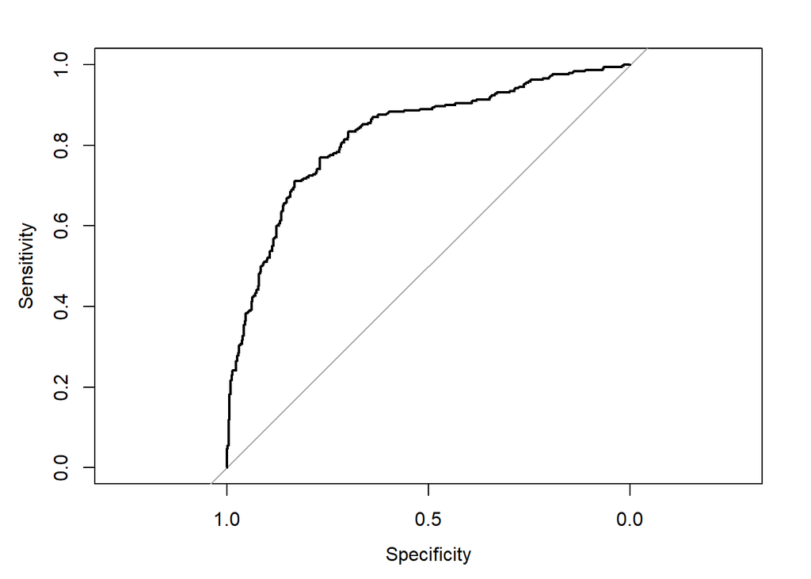

```r
prob <- predict(model_logit, type = "response")
roc_curve <- roc(data$Survived, prob)
plot(roc_curve)  # ROC曲线
```

```r
auc(roc_curve)   # AUC值（0.5~1，越大越好）
```

```
## Area under the curve: 0.8253
```

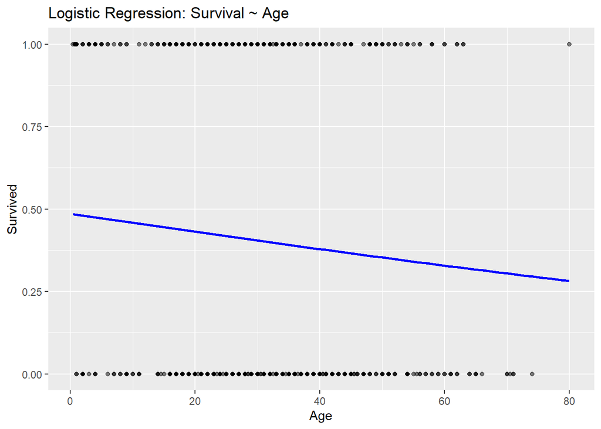

```r
# 可视化
ggplot(data, aes(x = Age, y = Survived)) +
  geom_point(alpha = 0.5) +
  geom_smooth(method = "glm",
              method.args = list(family = "binomial"),
              se = FALSE, color = "blue") +
  labs(title = "Logistic Regression: Survival ~ Age")
```

其他模型：泊松回归、岭回归

**岭回归/套索回归（Ridge/Lasso Regression）：**用于**高维数据**或**共线性较强**的情况：

```r
library(glmnet)
```

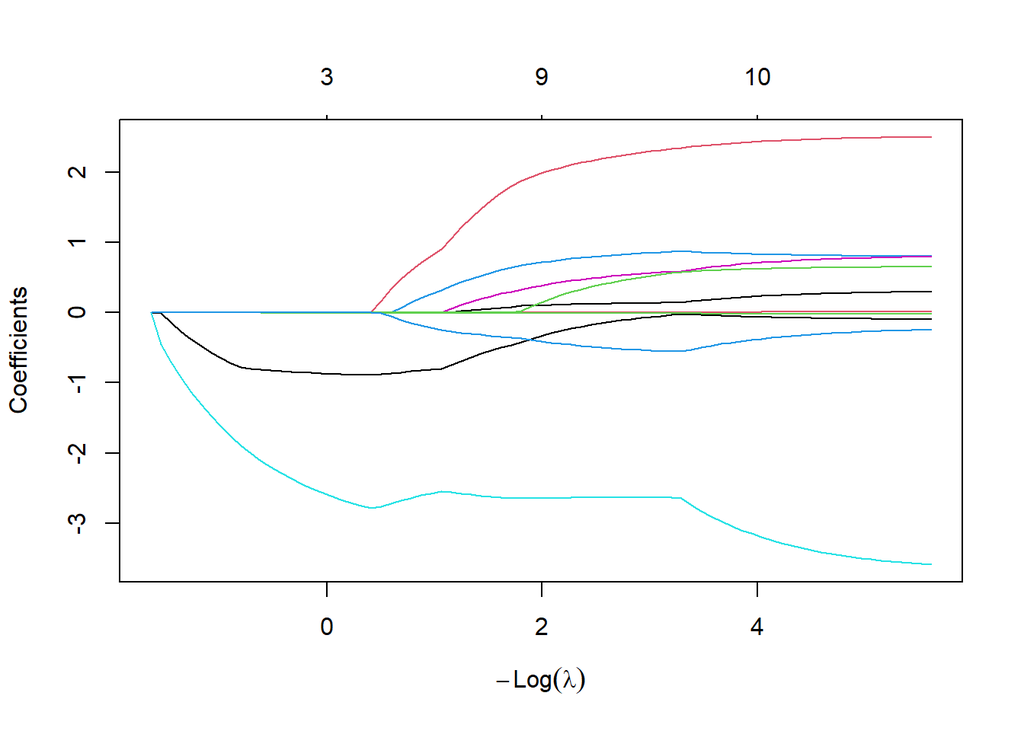

```r
x <- model.matrix(mpg ~ ., mtcars)[, -1]  # 自变量矩阵
y <- mtcars$mpg                           # 因变量
model_lasso <- glmnet(x, y, alpha = 1)    # alpha=1为Lasso，0为Ridge
plot(model_lasso, xvar = "lambda")        # 变量选择路径
```

模型比较与选择

比较AIC BIC

```r
AIC(model_lm, model_lm_multi)  # AIC越小越好
```

```
##                df      AIC
## model_lm        3 166.0294
## model_lm_multi  4 156.6523
```

```r
BIC(model_lm, model_lm_multi)  # BIC越小越好
```

```
##                df      BIC
## model_lm        3 170.4266
## model_lm_multi  4 162.5153
```

交叉验证

```r
library(caret)
train_control <- trainControl(method = "cv", number = 10)  # 10折交叉验证
model_cv <- train(mpg ~ wt + hp, data = mtcars,
                  method = "lm",
                  trControl = train_control)
print(model_cv)
```

```
## Linear Regression
##
## 32 samples
##  2 predictor
##
## No pre-processing
## Resampling: Cross-Validated (10 fold)
## Summary of sample sizes: 28, 29, 29, 28, 29, 29, ...
## Resampling results:
##
##   RMSE      Rsquared   MAE
##   2.598937  0.9014051  2.137284
##
## Tuning parameter 'intercept' was held constant at a value of TRUE
```